# Analysis workflow example

An Bui

2024-04-15

# 1. Set up

```r
# libraries
# general use
library(tidyverse)
library(janitor)
library(here)

# analysis
library(lme4)
library(lmerTest)
library(DHARMa)
library(MuMIn)

# model prediction visualizations
library(ggeffects)

# data
height_all <- read_csv(here("data", "final_height.csv")) %>%
  separate_wider_delim(specimen_id,
                       delim = "-",
                       names = c("date", "site", "individual", "specimen"),
                       cols_remove = FALSE) %>%
  unite("individual_id", date:individual, remove = TRUE, sep = "-")

perimeter_all <- read_csv(here("data", "final_perimeter.csv")) %>%
  separate_wider_delim(specimen_id,
                       delim = "-",
                       names = c("date", "site", "individual", "specimen"),
                       cols_remove = FALSE) %>%
  unite("individual_id", date:individual, remove = TRUE, sep = "-")
```

And here are some adjustments to keep the visualizations consistent:

```r
# ggplot theme
theme_set(theme_bw() +
            theme(panel.grid = element_blank()))

# abline color
ref_line_col <- "grey"

# model prediction color
model_col <- "darkblue"
```

# 2. Fitting different models and comparing them

## a. Model construction

In this part of the script, I’m fitting two different models for each trait: one where the interaction of species is included, and the other is where species are left out.

```r
# model 1: herbarium height only
height_m1 <- lmer(height_i ~ height_h + (1|individual_id), data = height_all)

# model 2: herbarium height with interaction of species
height_m2 <- lmer(height_i ~ height_h*species + (1|individual_id), data = height_all)
```

I’ll do the same thing for the perimeter data:

```r
# model 1: herbarium perimeter only
perimeter_m1 <- lmer(per_i ~ per_h + (1|individual_id), data = perimeter_all)

# model 2: herbarium perimeter with interaction of species
perimeter_m2 <- lmer(per_i ~ per_h*species + (1|individual_id), data = perimeter_all)
```

## b. Residual check

I’m going to check the residuals just in case, but we already know that the models are going to be overfitted. The residuals for height:

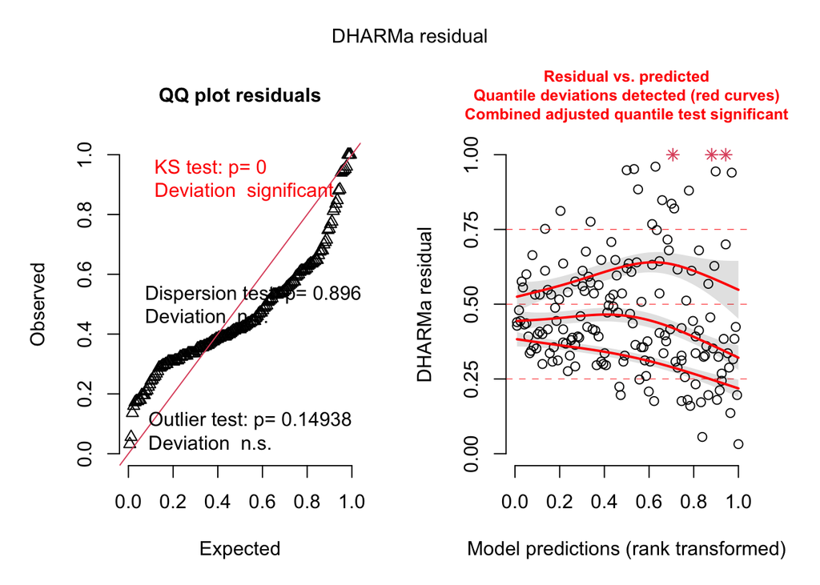

```
## Object of Class DHARMa with simulated residuals based on 250 simulations with refit = FALSE . See ?DHARMa::simulateResiduals for help.
##
## Scaled residual values: 0.428 0.172 0.44 0.36 0.16 0.268 0.3 0.308 0.26 0.392 0.328 0.416 0.196 0.46 0.356 0.372 0.336 0.752 0.368 0.312 ...
```

```r
simulateResiduals(height_m1, plot = TRUE)
```

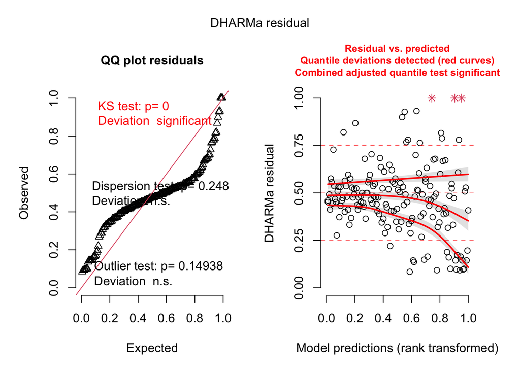

```
## Object of Class DHARMa with simulated residuals based on 250 simulations with refit = FALSE . See ?DHARMa::simulateResiduals for help.
##
## Scaled residual values: 0.46 0.344 0.452 0.668 0.372 0.548 0.404 0.512 0.136 0.364 0.576 0.52 0.508 0.556 0.504 0.492 0.476 0.82 0.476 0.56 ...
```

```r
simulateResiduals(height_m2, plot = TRUE)
```

And for perimeter:

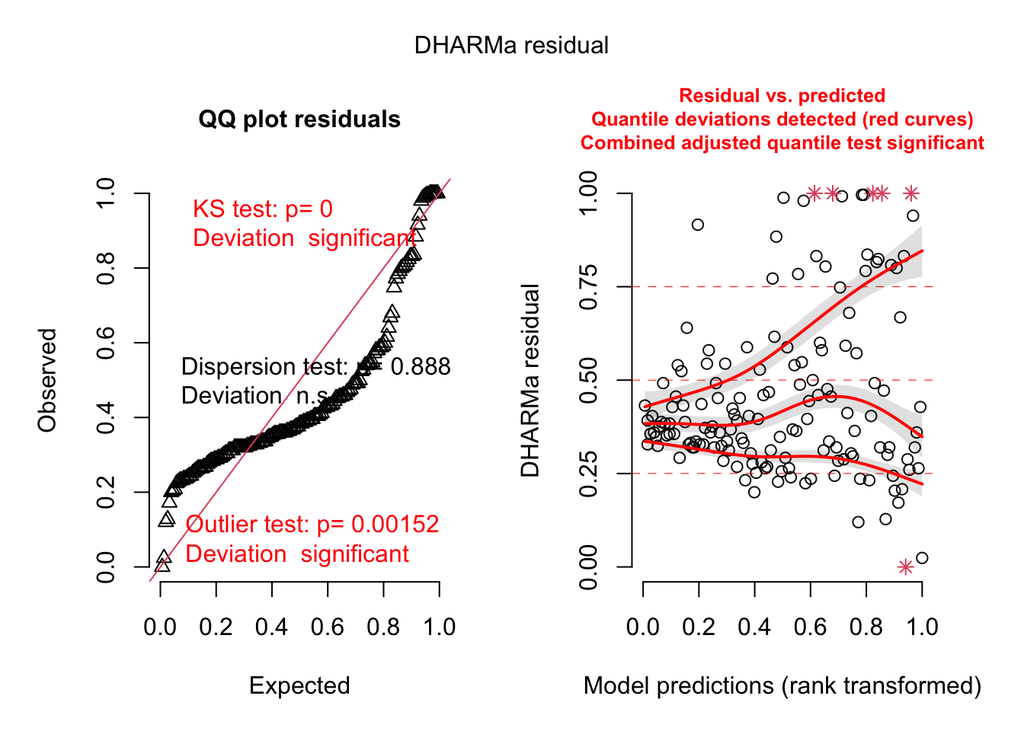

```
## Object of Class DHARMa with simulated residuals based on 250 simulations with refit = FALSE . See ?DHARMa::simulateResiduals for help.
##
## Scaled residual values: 0.544 0.452 0.232 0.284 0.356 0.328 0.328 0.404 0.224 0.388 0.328 0.356 0.356 0.392 0.384 0.324 0.328 0.252 0.332 0.376 ...
```

```r
simulateResiduals(perimeter_m1, plot = TRUE)
```

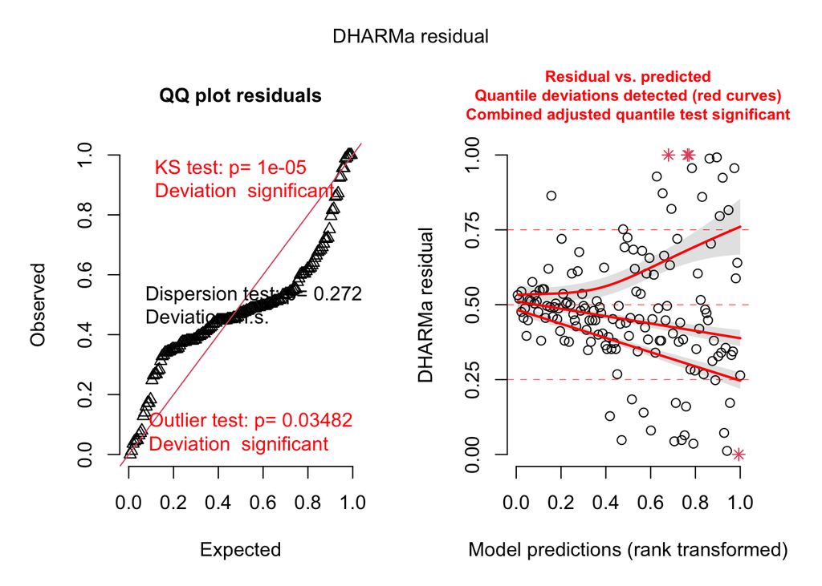

```
## Object of Class DHARMa with simulated residuals based on 250 simulations with refit = FALSE . See ?DHARMa::simulateResiduals for help.
##
## Scaled residual values: 0.72 0.676 0.416 0.412 0.512 0.46 0.452 0.52 0.44 0.512 0.456 0.456 0.504 0.544 0.532 0.488 0.476 0.448 0.496 0.516 ...
```

```r
simulateResiduals(perimeter_m2, plot = TRUE)
```

## c. Model summaries

Then, I’m going to look at the summary objects for height:

```r
summary(height_m1)
```

```
## Linear mixed model fit by REML. t-tests use Satterthwaite's method [
## lmerModLmerTest]
## Formula: height_i ~ height_h + (1 | individual_id)
##    Data: height_all
##
## REML criterion at convergence: 783.7
##
## Scaled residuals:
##     Min      1Q  Median      3Q     Max
## -1.9741 -0.4023 -0.1279  0.1446  7.3759
##
## Random effects:
##  Groups        Name        Variance Std.Dev.
##  individual_id (Intercept) 0.8207   0.9059
##  Residual                  5.5105   2.3474
## Number of obs: 167, groups:  individual_id, 54
##
## Fixed effects:
##              Estimate Std. Error        df t value Pr(>|t|)
## (Intercept)   0.25808    0.46707 115.71914   0.553    0.582
## height_h      1.13738    0.02731 139.85308  41.641   <2e-16 ***
## ---
## Signif. codes:  0 '***' 0.001 '**' 0.01 '*' 0.05 '.' 0.1 ' ' 1
##
## Correlation of Fixed Effects:
##          (Intr)
## height_h -0.880
```

```r
summary(height_m2)
```

```
## Linear mixed model fit by REML. t-tests use Satterthwaite's method [
## lmerModLmerTest]
## Formula: height_i ~ height_h * species + (1 | individual_id)
##    Data: height_all
##
## REML criterion at convergence: 752
##
## Scaled residuals:
##     Min      1Q  Median      3Q     Max
## -1.3839 -0.3069 -0.0696  0.1275  7.4336
##
## Random effects:
##  Groups        Name        Variance Std.Dev.
##  individual_id (Intercept) 0.04431  0.2105
##  Residual                  5.53471  2.3526
## Number of obs: 167, groups:  individual_id, 54
##
## Fixed effects:
##                       Estimate Std. Error        df t value Pr(>|t|)
## (Intercept)            0.53223    1.52878 101.18822   0.348   0.7285
## height_h               1.08408    0.10738 117.09633  10.095   <2e-16 ***
## speciesCC             -2.62401    2.44318 134.06144  -1.074   0.2847
## speciesCO             -0.61692    2.23952  74.89845  -0.275   0.7837
## speciesCYOS            1.36457    3.52820 137.61217   0.387   0.6995
## speciesDL              5.36919    3.03593 144.86101   1.769   0.0791 .
## speciesDP              0.78055    1.92977  96.65881   0.404   0.6868
## speciesEGME           -0.31909    1.83980  96.77177  -0.173   0.8627
## speciesGR              1.50188    5.33634 112.08412   0.281   0.7789
## speciesNAND            0.04037    2.76399 141.33926   0.015   0.9884
## speciesPOLA           -0.15879    3.19891 143.87363  -0.050   0.9605
## speciesR              -0.20268    2.04852  91.93949  -0.099   0.9214
## height_h:speciesCC     0.25621    0.15139 133.99473   1.692   0.0929 .
## height_h:speciesCO    -0.01880    0.21540  72.49721  -0.087   0.9307
## height_h:speciesCYOS   0.05317    0.16504 136.64447   0.322   0.7478
## height_h:speciesDL    -0.19227    0.15126 144.71505  -1.271   0.2057
## height_h:speciesDP     0.04072    0.13133 110.99089   0.310   0.7571
## height_h:speciesEGME  -0.01431    0.12181 126.89901  -0.117   0.9067
## height_h:speciesGR    -0.11581    0.25850 104.85633  -0.448   0.6551
## height_h:speciesNAND  -0.03487    0.24531 135.14081  -0.142   0.8872
## height_h:speciesPOLA   0.02274    0.25690 120.08051   0.089   0.9296
## height_h:speciesR      0.01836    0.16646  93.30354   0.110   0.9124
## ---
## Signif. codes:  0 '***' 0.001 '**' 0.01 '*' 0.05 '.' 0.1 ' ' 1
```

```
##
## Correlation matrix not shown by default, as p = 22 > 12.
## Use print(x, correlation=TRUE)  or
##     vcov(x)        if you need it
```

And for perimeter:

```r
summary(perimeter_m1)
```

```
## Linear mixed model fit by REML. t-tests use Satterthwaite's method [
## lmerModLmerTest]
## Formula: per_i ~ per_h + (1 | individual_id)
##    Data: perimeter_all
##
## REML criterion at convergence: 1472.6
##
## Scaled residuals:
##     Min      1Q  Median      3Q     Max
## -4.8908 -0.3120 -0.0885  0.1870  4.6894
##
## Random effects:
##  Groups        Name        Variance Std.Dev.
##  individual_id (Intercept) 563.2    23.73
##  Residual                  573.3    23.94
## Number of obs: 153, groups:  individual_id, 52
##
## Fixed effects:
##              Estimate Std. Error        df t value Pr(>|t|)
## (Intercept)  10.01440    5.75140 103.30764   1.741   0.0846 .
## per_h         1.21717    0.04487 150.79674  27.126   <2e-16 ***
## ---
## Signif. codes:  0 '***' 0.001 '**' 0.01 '*' 0.05 '.' 0.1 ' ' 1
##
## Correlation of Fixed Effects:
##       (Intr)
## per_h -0.740
```

```r
summary(perimeter_m2)
```

```
## Linear mixed model fit by REML. t-tests use Satterthwaite's method [
## lmerModLmerTest]
## Formula: per_i ~ per_h * species + (1 | individual_id)
##    Data: perimeter_all
##
## REML criterion at convergence: 1361.8
##
## Scaled residuals:
##     Min      1Q  Median      3Q     Max
## -2.0987 -0.2817 -0.0422  0.1080  4.7679
##
## Random effects:
##  Groups        Name        Variance Std.Dev.
##  individual_id (Intercept) 225.6    15.02
##  Residual                  501.2    22.39
## Number of obs: 153, groups:  individual_id, 52
##
## Fixed effects:
##                    Estimate Std. Error        df t value Pr(>|t|)
## (Intercept)         2.59684   13.77863  88.26129   0.188 0.850942
## per_h               1.19298    0.10995 125.45680  10.850  < 2e-16 ***
## speciesCC          -6.82156   19.70908 103.74382  -0.346 0.729959
## speciesCO         -19.35573   23.91988 114.13986  -0.809 0.420089
## speciesCYOS         6.64731   21.07977 109.76272   0.315 0.753102
## speciesDP          34.33115   17.91760  88.87197   1.916 0.058572 .
## speciesEGME        -2.02207   19.61561 105.50238  -0.103 0.918091
## speciesGR           1.05566   22.86537  80.61552   0.046 0.963290
## speciesNAND       -19.63704   47.84044  78.89181  -0.410 0.682574
## speciesPOLA       147.31861   41.95239 132.97267   3.512 0.000609 ***
## speciesR           -1.44377   18.60890  89.93418  -0.078 0.938330
## per_h:speciesCC     0.11400    0.22636 126.28471   0.504 0.615398
## per_h:speciesCO     0.18647    0.24758 132.38146   0.753 0.452687
## per_h:speciesCYOS  -0.11782    0.13820 132.81018  -0.853 0.395437
## per_h:speciesDP     0.10835    0.13834 122.61000   0.783 0.434995
## per_h:speciesEGME  -0.09324    0.29545 110.83387  -0.316 0.752910
## per_h:speciesGR     0.03776    0.19031 116.97364   0.198 0.843049
## per_h:speciesNAND   0.20992    0.35881  95.46443   0.585 0.559902
## per_h:speciesPOLA  -1.03952    0.28146 106.94185  -3.693 0.000351 ***
## per_h:speciesR      0.09234    0.17917 132.89084   0.515 0.607163
## ---
## Signif. codes:  0 '***' 0.001 '**' 0.01 '*' 0.05 '.' 0.1 ' ' 1
```

```
##
## Correlation matrix not shown by default, as p = 20 > 12.
## Use print(x, correlation=TRUE)  or
##     vcov(x)        if you need it
```

It looks like herbarium height significantly predicts initial height, no matter what. Similarly, herbarium perimeter predicts initial perimeter.

## d. Model selection

Now, I’m going to compare models using AIC using `MuMIn::model.sel()`.

```r
model.sel(height_m1, height_m2)
```

```
## Model selection table
##            (Int) hgh_h spc hgh_h:spc df   logLik  AICc delta weight
## height_m1 0.2581 1.137                4 -391.826 791.9  0.00      1
## height_m2 0.5322 1.084   +         + 24 -376.005 808.5 16.56      0
## Models ranked by AICc(x)
## Random terms (all models):
##   1 | individual_id
```

And for perimeter:

```r
model.sel(perimeter_m1, perimeter_m2)
```

```
## Model selection table
##               (Int) per_h spc per_h:spc df   logLik   AICc delta weight
## perimeter_m2  2.597 1.193   +         + 22 -680.895 1413.6  0.00      1
## perimeter_m1 10.010 1.217                4 -736.285 1480.8 67.27      0
## Models ranked by AICc(x)
## Random terms (all models):
##   1 | individual_id
```

The Akaike Information Criterion gives you an AIC value for each model. The AIC penalizes complex models, even though they might explain more of the variation in the response. The model with the lower AIC is the “better” model. In this case, `height_m1`, which is the model without the interaction of species, is the “better” model. For perimeter, `perimeter_m2`, which is the model with the interaction of species, is the “better” model.

Taken together, what you would be able to say is that for some traits, species matter for determining the relationship between herbarium and initial measurements. For height, species don’t matter because the “better” model is the one without species; in contrast, for perimeter, species do matter because the “better” model is the one with species.

## e. Calculating R<sup>2</sup> values

Now, I’ll calculate the R<sup>2</sup> values for the selected models. For height:

```r
MuMIn::r.squaredGLMM(height_m1)
```

```
##            R2m       R2c
## [1,] 0.9182208 0.9288213
```

And for perimeter:

```r
MuMIn::r.squaredGLMM(perimeter_m2)
```

```
##            R2m       R2c
## [1,] 0.8997358 0.9308613
```

This function gives you two R<sup>2</sup> values: a “marginal” R<sup>2</sup> and a “conditional” R<sup>2</sup>. The marginal R<sup>2</sup> gives you the variation explained only by fixed (i.e. not random) effects, and the conditional R<sup>2</sup> gives you the variation explained by both fixed and random effects. When reporting R<sup>2</sup> for mixed models, it’s useful to report both.

# 3. Visualizing

## a. Visualizing model without species interaction

For height, the best model is the one without species. Ultimately, the plot will have points representing the specimens with a line representing the linear relationship between herbarium height and initial height with a confidence interval.

First, I’ll get the model predictions from `ggpredict()`:

```r
# get predictions and save as object
# constraining the range of predictions from 0 to 45 mm (maximum herbarium height is 41.6)
height_predictions <- ggpredict(height_m1, terms = "height_h[0:45]")

# look at the data frame
height_predictions
```

```
## # Predicted values of height_i
##
## height_h | Predicted |       95% CI
## -----------------------------------
##        0 |      0.26 | -0.66,  1.18
##        6 |      7.08 |  6.43,  7.74
##       11 |     12.77 | 12.28, 13.26
##       17 |     19.59 | 19.14, 20.04
##       23 |     26.42 | 25.80, 27.03
##       28 |     32.10 | 31.28, 32.93
##       34 |     38.93 | 37.82, 40.04
##       45 |     51.44 | 49.77, 53.11
##
## Adjusted for:
## * individual_id = 0 (population-level)
```

```
##
## Not all rows are shown in the output. Use `print(..., n = Inf)` to show
##   all rows.
```

Then, I’ll plot the model predictions on top of the raw data:

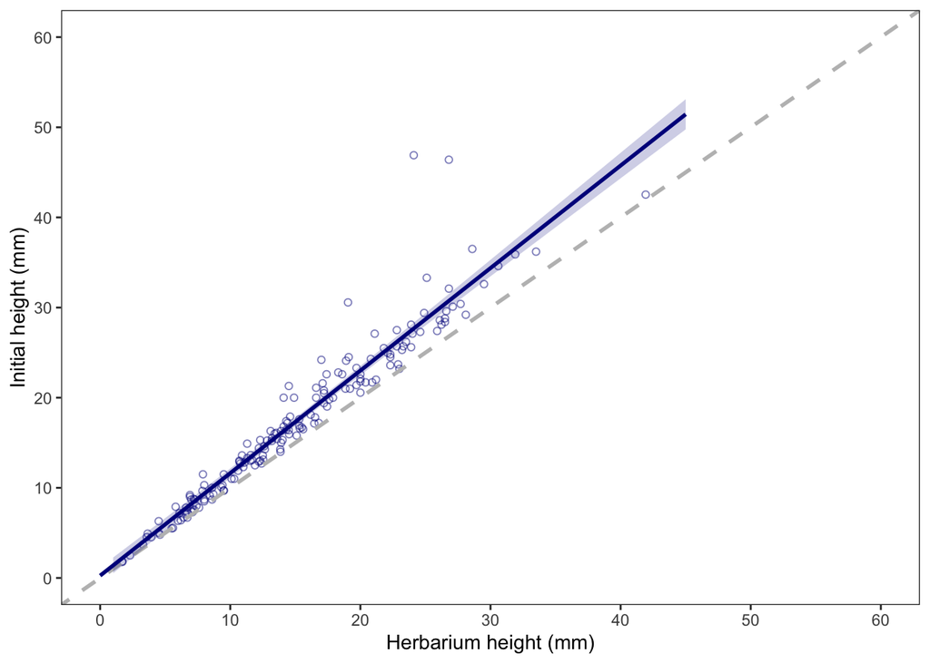

```r
height_model_plot <- ggplot() +

  # plot the raw data as points
  geom_point(data = height_all,
             aes(x = height_h,
                 y = height_i),
             alpha = 0.5,
             color = model_col,
             shape = 21) +

  # plot a 1:1 reference line
  geom_abline(slope = 1,
              intercept = 0,
              linetype = 2,
              linewidth = 1,
              color = ref_line_col) +

  # plot the confidence interval
  geom_ribbon(data = height_predictions,
              aes(x = x,
                  y = predicted,
                  ymin = conf.low,
                  ymax = conf.high),
              alpha = 0.2,
              fill = model_col) +

  # plot the prediction line
  geom_line(data = height_predictions,
            aes(x = x,
                y = predicted),
            color = model_col,
            linewidth = 1) +

  # labels
  labs(x = "Herbarium height (mm)",
       y = "Initial height (mm)") +

  # controlling axes to make the plot look square
  # this makes it easier to see the difference between the model and the 1:1 line
  scale_x_continuous(breaks = seq(from = 0, to = 60, by = 10),
                     limits = c(0, 60)) +
  scale_y_continuous(breaks = seq(from = 0, to = 60, by = 10),
                     limits = c(0, 60))


height_model_plot
```

## b. Visualizing model with species interaction

For perimeter, the best model is the one with species. So now, I’ll extract the model predictions for both `per_h` and `species`.

```r
# get predictions and save as object
perimeter_predictions_nospecies <- ggpredict(perimeter_m2, terms = c("per_h")) %>%
  as_tibble()

perimeter_predictions_species <- ggpredict(perimeter_m2, terms = c("per_h", "species")) %>%
  as_tibble() %>%
  rename(species = group)

# look at the data frames
perimeter_predictions_nospecies
```

```
## # A tibble: 18 × 6
##        x predicted std.error conf.low conf.high group
##    <dbl>     <dbl>     <dbl>    <dbl>     <dbl> <fct>
##  1     0      2.60     13.8    -24.7       29.9 1
##  2    20     26.5      12.1      2.58      50.3 1
##  3    40     50.3      10.5     29.5       71.2 1
##  4    60     74.2       9.28    55.8       92.5 1
##  5    80     98.0       8.43    81.4      115.  1
##  6   100    122.        8.09   106.       138.  1
##  7   120    146.        8.34   129.       162.  1
##  8   140    170.        9.13   152.       188.  1
##  9   160    193.       10.3    173.       214.  1
## 10   180    217.       11.8    194.       241.  1
## 11   200    241.       13.5    214.       268.  1
## 12   220    265.       15.3    235.       295.  1
## 13   240    289.       17.3    255.       323.  1
## 14   260    313.       19.2    275.       351.  1
## 15   280    337.       21.2    295.       379.  1
## 16   300    360.       23.3    314.       407.  1
## 17   320    384.       25.4    334.       435.  1
## 18   340    408.       27.5    354.       463.  1
```

```r
perimeter_predictions_species
```

```
## # A tibble: 180 × 6
##        x predicted std.error conf.low conf.high species
##    <dbl>     <dbl>     <dbl>    <dbl>     <dbl> <fct>
##  1     0     2.60       13.8    -24.7      29.9 BF
##  2     0    -4.22       14.1    -32.1      23.7 CC
##  3     0   -16.8        19.6    -55.4      21.9 CO
##  4     0     9.24       16.0    -22.3      40.8 CYOS
##  5     0    36.9        11.5     14.3      59.6 DP
##  6     0     0.575      14.0    -27.0      28.2 EGME
##  7     0     3.65       18.2    -32.4      39.8 GR
##  8     0   -17.0        45.8   -108.       73.6 NAND
##  9     0   150.         39.6     71.5     228.  POLA
## 10     0     1.15       12.5    -23.6      25.9 R
## # ℹ 170 more rows
```

Then, I’ll plot the model predictions on top of the raw data, but only the predictor of herbarium perimeter:

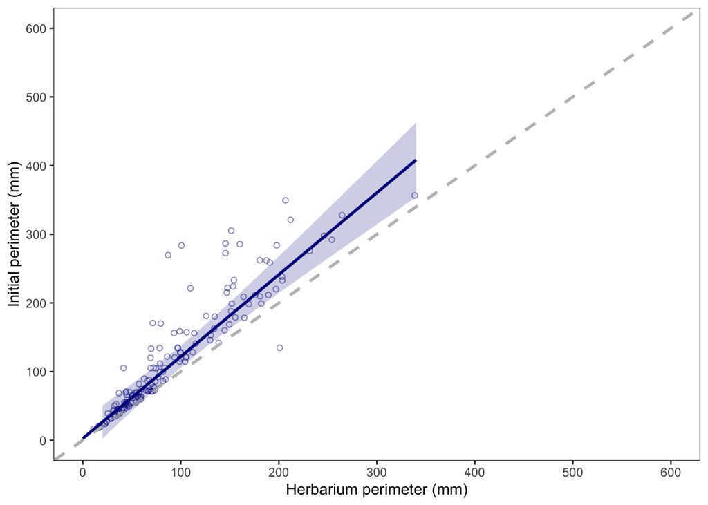

```r
perimeter_model_plot <- ggplot() +

  # plot the raw data as points
  geom_point(data = perimeter_all,
             aes(x = per_h,
                 y = per_i),
             alpha = 0.5,
             color = model_col,
             shape = 21) +

  # plot a 1:1 reference line
  geom_abline(slope = 1,
              intercept = 0,
              linetype = 2,
              linewidth = 1,
              color = ref_line_col) +

  # plot the confidence interval
  geom_ribbon(data = perimeter_predictions_nospecies,
              aes(x = x,
                  y = predicted,
                  ymin = conf.low,
                  ymax = conf.high),
              alpha = 0.2,
              fill = model_col) +

  # plot the prediction line
  geom_line(data = perimeter_predictions_nospecies,
            aes(x = x,
                y = predicted),
            color = model_col,
            linewidth = 1) +

  # labels
  labs(x = "Herbarium perimeter (mm)",
       y = "Initial perimeter (mm)") +

  # controlling axes to make the plot look square
  # this makes it easier to see the difference between the model and the 1:1 line
  scale_x_continuous(breaks = seq(from = 0, to = 600, by = 100),
                     limits = c(0, 600)) +
  scale_y_continuous(breaks = seq(from = 0, to = 600, by = 100),
                     limits = c(0, 600))

perimeter_model_plot
```

Then, I’ll plot each individual species with its own prediction line:

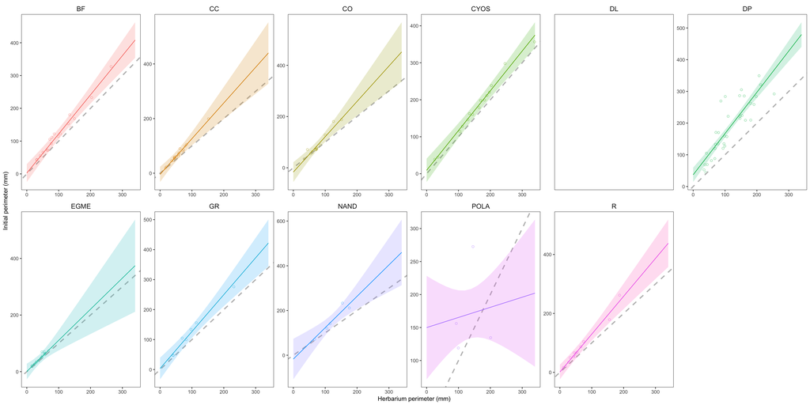

```r
perimeter_species_plot <- ggplot() +

  # plot the raw data as points
  geom_point(data = perimeter_all,
             aes(x = per_h,
                 y = per_i,
                 color = species),
             alpha = 0.5,
             shape = 21) +

  # plot a 1:1 reference line
  geom_abline(slope = 1,
              intercept = 0,
              linetype = 2,
              linewidth = 1,
              color = ref_line_col) +

  # plot the confidence intervals
  geom_ribbon(data = perimeter_predictions_species,
            aes(x = x,
                y = predicted,
                ymin = conf.low,
                ymax = conf.high,
                fill = species,
                group = species),
            alpha = 0.2) +

  # plot the model predictions
  geom_line(data = perimeter_predictions_species,
            aes(x = x,
                y = predicted,
                color = species,
                group = species)) +

  # labels
  labs(x = "Herbarium perimeter (mm)",
       y = "Initial perimeter (mm)") +

  # theme
  theme(legend.position = "none",
        strip.background = element_blank(),
        strip.text = element_text(size = 12)) +

  # facet
  facet_wrap(~ species, nrow = 2,
             scales = "free")


perimeter_species_plot
```

This is probably a plot for the supplemental material. The plot shows the slopes for each species, and the model predictions follow the same pattern as height (on average, herbarium perimeter is slightly lower than initial perimeter), but the only exception to this is POLA. This could be for a number of reasons, but based on the plot I would hypothesize that the unusual line is because there are only a few observations for that species.